# module 6 report

vroomvroom

2022-10-27

## Introduction

The Lepidopteras comprise of about 160,000 different species and are best known for their diversity in terms of hind and forewings. It’s been observed that their hind and forewings both play a separate role in flight. For example, butterflies are able to fly with just their forewings however, at a slower speed with less fluidity. Each species of Lepidoptera has a unique shape and wing pattern, however, the differences between each species brings up the question of whether or not Lepidopteras have evolved to favor a larger forewing or hindwing, or to favor a smaller forewing to hindwing ratio. While looking at their wings, it is important to note that there are variations within species as wing size within certain species, especially those who migrate, “could be influenced by other environmental factors depending on where butterflies are hatched and grow up” [freedman2020two]. This project served to find trends within their wing evolution to see if a certain proportion was selected for within Lepidoptera evolution.

## Methods

To test whether or not a certain proportion of forewing to hindwing ratio is favored in terms of Lepidoptera evolution photos of lepidopteras sourced from the Global Biodiversity Information Facility were analyzed using a program called FIJI. The first part of the project consisted of digitizing images of hind and forewings. The pair of wings on the right side of the screen were analysed, and if a specimen had a damaged wing on the right, the image was flipped. When using the polygon tool to outline the wings, it was ensure that the origin of the tracing points stayed relatively the same from wing to wing, as close to the body of the butterfly as possible on the top of the wing. About 30 points were used to trace the wings, and a macro was ran to fit a spline between the points. These results were then saved, each specimen outlined had a data set for their forewing and their hindwing (between one and three specimen were outline for each species).

The second part of this project consisted of an R analysis through which the shapes and evolution of wings, as well as the shifts and correlations related to those. The main analyses that were run are: Elliptical Fourier analysis (EFA), Principal Component analysis (PCA), a noncenscored test, and Phylogenetic Independent Contrasts (PIC) analysis.

## Results

Once the forewing and hindwing data was separated into different data sets to analyze each and compare, and a Procrustes transformation was conducted for shape analysis, then the elliptical Fourier analysis (EFA) and Principle Components Analysis (PCA) could be performed. We found that for the forewings, PC1 described 69.1% of the variation within species and PC2 described 11.5%, together they described 80.6% of variation. For the hindwing, the PCs were a little more powerful. PC1 described 46.1% of variation, and PC2 37.7%, so together they described 83.8% of variation.

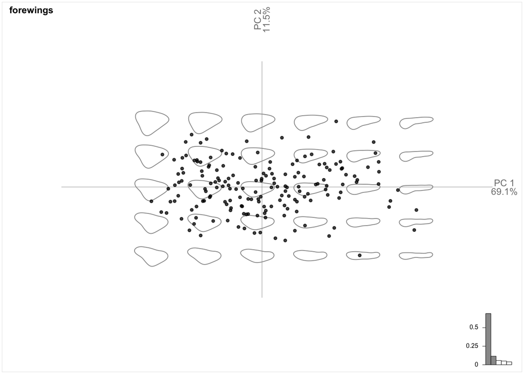

PCA distribution of PC 1 and PC 2 for the forewing

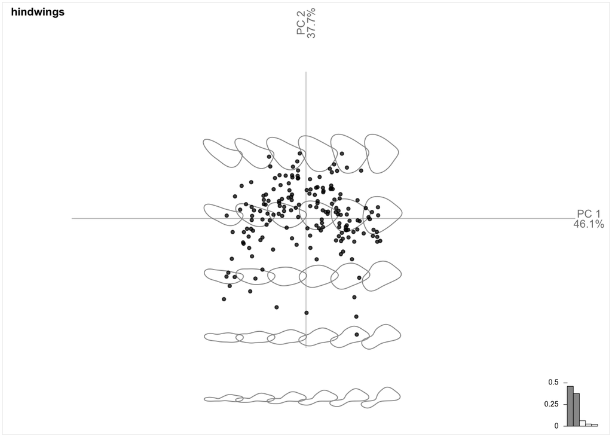

PCA distribution of PC 1 and PC 2 for the hindwing

To answer the first question of whether the rates of wing-shape evolution were different between the hind- and forewing, the evolutionary rates of the PC scores can be evaluated. These values were stored for each wing with PC1 and PC2, using the noncensored test. We found the forewing PC1 score to be 0.006535527, the hindwing PC1 to be 0.01014157, the forewing PC2 to be 0.002411568, and the hindwing PC2 to be 0.01870921.

```r
forePC1.BM$sig2.single
```

```
## [1] 0.006535527
```

```r
hindPC1.BM$sig2.single
```

```
## [1] 0.01014157
```

```r
forePC2.BM$sig2.single
```

```
## [1] 0.002411568
```

```r
hindPC2.BM$sig2.single
```

```
## [1] 0.01870921
```

To answer the second question of whether major lineages of the Lepidoptera have undergone significant shifts in evolutionary rate, we can use the evolutionary rates of the PC scores across the Lepidopteran tree. The nodes with exceptional shifts can be visualized in the produced phylogentic trees, highlighted by a blue downwards triangle for low shifts or a red upwards triangle for high shifts. Our data show a blue downwards triangle for Macroheterocera: Noctuoidea for both fore- and hindwing PC1, and forewing PC2, while hindwing PC2 resulted in a blue downwards arrow for crown-Obtectomera: Papilionoidea.

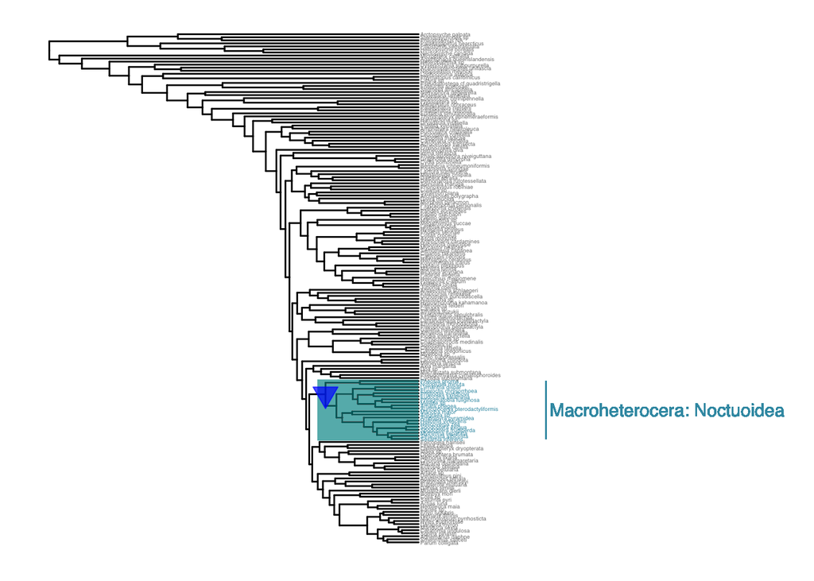

The Lepidoptery lineage, with a significant evolutionary low shift of PC 1 in the forewing highlighted

```
## # A tibble: 1 × 4
##       n rate.difference p.value clade
##   <dbl>           <dbl>   <dbl> <chr>
## 1   225        -0.00162   0.001 Macroheterocera: Noctuoidea
```

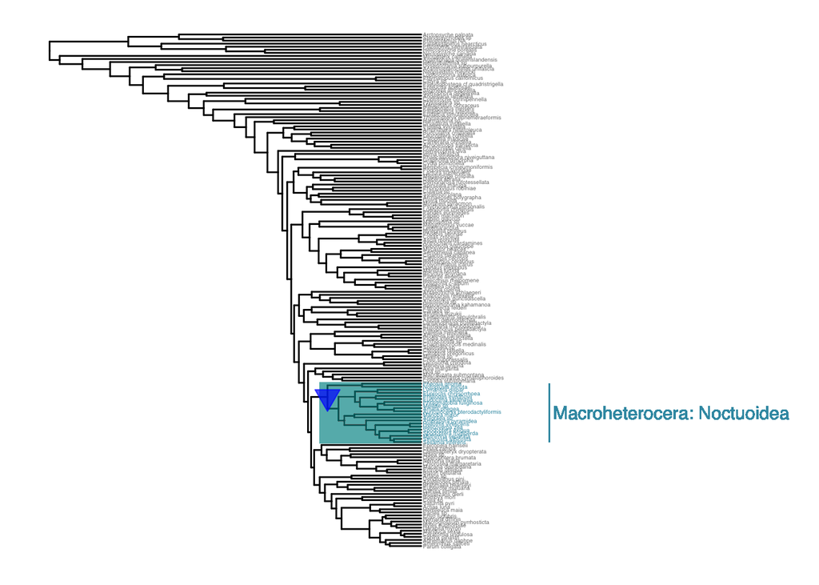

The Lepidoptery lineage, with a significant evolutionary low shift of PC 1 in the hindwing highlighted

```
## # A tibble: 1 × 4
##       n rate.difference p.value clade
##   <dbl>           <dbl>   <dbl> <chr>
## 1   225        -0.00194   0.001 Macroheterocera: Noctuoidea
```

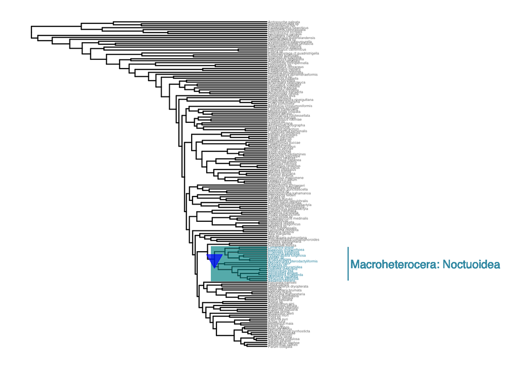

The Lepidoptery lineage, with a significant evolutionary low shift of PC 2 in the forewing highlighted

```
## # A tibble: 1 × 4
##       n rate.difference p.value clade
##   <dbl>           <dbl>   <dbl> <chr>
## 1   226       -0.000597   0.001 Macroheterocera: Noctuoidea
```

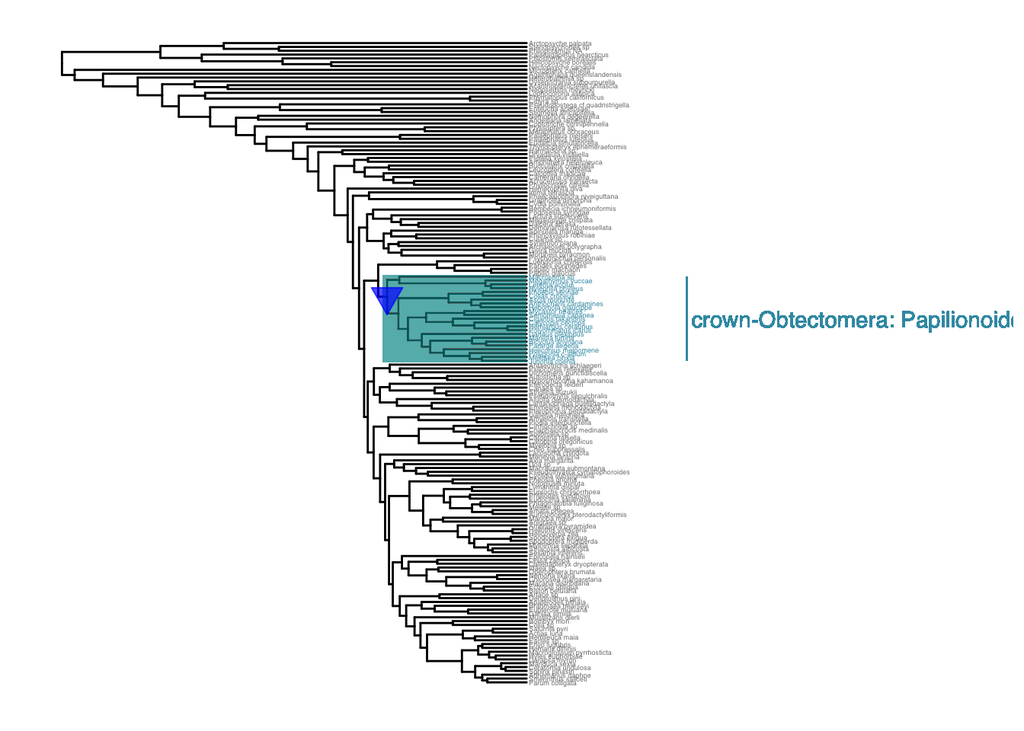

The Lepidoptery lineage, with a significant evolutionary low shift of PC 2 in the hindwing highlighted

```
## # A tibble: 1 × 4
##       n rate.difference p.value clade
##   <dbl>           <dbl>   <dbl> <chr>
## 1   271        -0.00161   0.001 crown-Obtectomera: Papilionoidea
```

Finally, the last question pertaining to the correlation of the hind- and forewing is addressed by the phylogenetic independent contrasts (PIC) analysis. These linear models plot the original tip data transformed using phylogenetic information for hind- and forewing PC1, and hind- and forewing PC2. The first plot of hind- and forewing PC1 shows a negatively sloped line of fit while the second plot of hind- and forewing PC2 shows a slight postive slope. The r-squared values can be used to determine significance in the relationships, with values of 0.4442 and -0.001955 respectively.

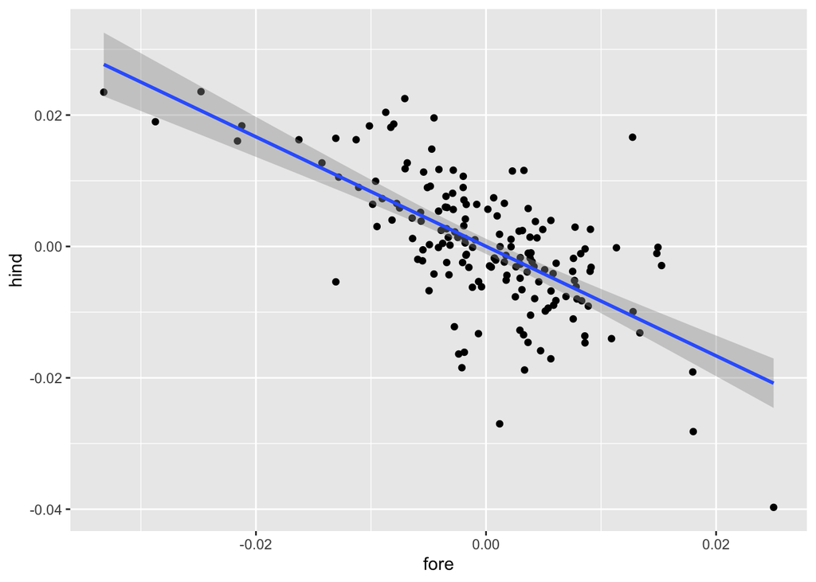

The linear model of PC1 in hindwing and forewing after PIC analysis

```
##
## Call:
## lm(formula = hind ~ fore, data = PC1.pic)
##
## Residuals:
##        Min         1Q     Median         3Q        Max
## -0.0260329 -0.0040299 -0.0001764  0.0048320  0.0272273
##
## Coefficients:
##               Estimate Std. Error t value Pr(>|t|)
## (Intercept)  1.629e-05  5.845e-04   0.028    0.978
## fore        -8.335e-01  7.209e-02 -11.562   <2e-16 ***
## ---
## Signif. codes:  0 '***' 0.001 '**' 0.01 '*' 0.05 '.' 0.1 ' ' 1
##
## Residual standard error: 0.007552 on 165 degrees of freedom
## Multiple R-squared:  0.4476, Adjusted R-squared:  0.4442
## F-statistic: 133.7 on 1 and 165 DF,  p-value: < 2.2e-16
```

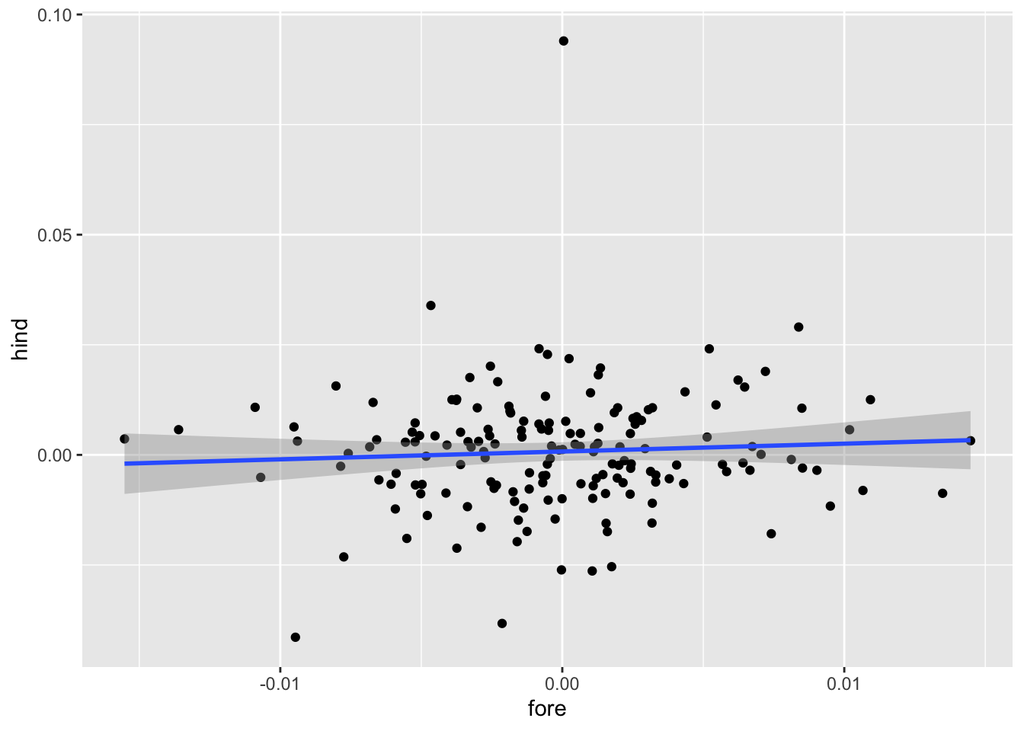

The linear model of PC2 in hindwing and forewing after PIC analysis

```
##
## Call:
## lm(formula = hind ~ fore, data = PC2.pic)
##
## Residuals:
##       Min        1Q    Median        3Q       Max
## -0.040493 -0.007104  0.000357  0.006907  0.093219
##
## Coefficients:
##              Estimate Std. Error t value Pr(>|t|)
## (Intercept) 0.0007655  0.0010652   0.719    0.473
## fore        0.1778140  0.2162627   0.822    0.412
##
## Residual standard error: 0.01375 on 165 degrees of freedom
## Multiple R-squared:  0.00408,    Adjusted R-squared:  -0.001955
## F-statistic: 0.676 on 1 and 165 DF,  p-value: 0.4121
```

## Discussion

For both PC’s, the hindwing has a larger rate of evolution compared to the forewing. For PC1, the hindwing was 1.55 times greater than the forewing. PC2 showed an even larger difference, with a 7.76 times difference favoring the hindwing over the forewing. Our investigations into specific lineage with significant evolutionary rate showed only two groups: the Noctuoidea and the Papilionidea. The Noctuoidea had a significantly low shift in PC1 for the forewing and hindwing, and a low shift in the PC2 of the forewing, while the Papilionidea had a significantly low shift in the PC2 of the hindwing. The phylogenetic independent contrasts (PIC) analysis revealed that for PC1 there is a significant negative correlation between hindwing and forewing shape, but there is no significant correlation PC2. Our study found that the forewing evolved at a slower evolutionary rate than the hindwing, supporting the idea that stabilizing selection is involved in forewing evolution. Despite this, our analysis showed a correlation in the shape of the different wings. The linked evolution may support the like that, while the forewing is primarily helpful for flight, the hindwing allows for better control during flight [jantzen2008hindwings]. Furthermore, it was shown that there are significantly low evolutionary rate shifts in a couple of Lepidoptera lineages.

## Author Contributions

SF did the introduction and the methods section. LE worked on the results sections. SM wrote the discussion.CP did the coding for this project and made sure the projec was cohesive and worked on the HTML output.